# bikers_GoogleCapstone

Daniel Fidalgo

11/30/2021

## 1. Ask

### 1.1 The objective

- How do annual members and casual members use bikes differently?
- How to convert casual riders into annual members?

## 2. Prepare

### 2.1 Download the required data

In this case, we are using the last 12 months of data provided by the stakeholders company.

```r
#Load the data from the last 12 months
biker_10_2021 <- read_csv("bikers_data/202110-divvy-tripdata/202110-divvy-tripdata.csv") # October 2021
biker_09_2021 <- read_csv("bikers_data/202109-divvy-tripdata/202109-divvy-tripdata.csv") # September 2021
biker_08_2021 <- read_csv("bikers_data/202108-divvy-tripdata/202108-divvy-tripdata.csv") # August 2021
biker_07_2021 <- read_csv("bikers_data/202107-divvy-tripdata/202107-divvy-tripdata.csv") # July 2021
biker_06_2021 <- read_csv("bikers_data/202106-divvy-tripdata/202106-divvy-tripdata.csv") # June 2021
biker_05_2021 <- read_csv("bikers_data/202105-divvy-tripdata/202105-divvy-tripdata.csv") # May 2021
biker_04_2021 <- read_csv("bikers_data/202104-divvy-tripdata/202104-divvy-tripdata.csv") # April 2021
biker_03_2021 <- read_csv("bikers_data/202103-divvy-tripdata/202103-divvy-tripdata.csv") # March 2021
biker_02_2021 <- read_csv("bikers_data/202102-divvy-tripdata/202102-divvy-tripdata.csv") # February 2021
biker_01_2021 <- read_csv("bikers_data/202101-divvy-tripdata/202101-divvy-tripdata.csv") # January 2021
biker_12_2020 <- read_csv("bikers_data/202012-divvy-tripdata/202012-divvy-tripdata.csv") # December 2020
biker_11_2020 <- read_csv("bikers_data/202011-divvy-tripdata/202011-divvy-tripdata.csv") # November 2020
#Pool the data into a single data.frame
bikers_pooled <- rbind(biker_10_2021, biker_09_2021, biker_08_2021, biker_07_2021, biker_06_2021, biker_05_2021, biker_04_2021, biker_03_2021, biker_02_2021,biker_01_2021, biker_12_2020, biker_11_2020)
```

### 2.2 Identify the how the data is organized

```r
# Look at the data structure
glimpse(bikers_pooled)
```

```
## Rows: 5,378,834
## Columns: 13
## $ ride_id            <chr> "620BC6107255BF4C", "4471C70731AB2E45", "26CA69D43D~
## $ rideable_type      <chr> "electric_bike", "electric_bike", "electric_bike", ~
## $ started_at         <dttm> 2021-10-22 12:46:42, 2021-10-21 09:12:37, 2021-10-~
## $ ended_at           <dttm> 2021-10-22 12:49:50, 2021-10-21 09:14:14, 2021-10-~
## $ start_station_name <chr> "Kingsbury St & Kinzie St", NA, NA, NA, NA, NA, NA,~
## $ start_station_id   <chr> "KA1503000043", NA, NA, NA, NA, NA, NA, NA, NA, NA,~
## $ end_station_name   <chr> NA, NA, NA, NA, NA, NA, NA, NA, NA, NA, NA, NA, NA,~
## $ end_station_id     <chr> NA, NA, NA, NA, NA, NA, NA, NA, NA, NA, NA, NA, NA,~
## $ start_lat          <dbl> 41.88919, 41.93000, 41.92000, 41.92000, 41.89000, 4~
## $ start_lng          <dbl> -87.63850, -87.70000, -87.70000, -87.69000, -87.710~
## $ end_lat            <dbl> 41.89000, 41.93000, 41.94000, 41.92000, 41.89000, 4~
## $ end_lng            <dbl> -87.63000, -87.71000, -87.72000, -87.69000, -87.690~
## $ member_casual      <chr> "member", "member", "member", "member", "member", "~
```

```r
colnames(bikers_pooled)
```

```
##  [1] "ride_id"            "rideable_type"      "started_at"
##  [4] "ended_at"           "start_station_name" "start_station_id"
##  [7] "end_station_name"   "end_station_id"     "start_lat"
## [10] "start_lng"          "end_lat"            "end_lng"
## [13] "member_casual"
```

```r
head(bikers_pooled)
```

```
## # A tibble: 6 x 13
##   ride_id rideable_type started_at          ended_at            start_station_n~
##   <chr>   <chr>         <dttm>              <dttm>              <chr>
## 1 620BC6~ electric_bike 2021-10-22 12:46:42 2021-10-22 12:49:50 Kingsbury St & ~
## 2 4471C7~ electric_bike 2021-10-21 09:12:37 2021-10-21 09:14:14 <NA>
## 3 26CA69~ electric_bike 2021-10-16 16:28:39 2021-10-16 16:36:26 <NA>
## 4 362947~ electric_bike 2021-10-16 16:17:48 2021-10-16 16:19:03 <NA>
## 5 BB731D~ electric_bike 2021-10-20 23:17:54 2021-10-20 23:26:10 <NA>
## 6 717630~ electric_bike 2021-10-21 16:57:37 2021-10-21 17:11:58 <NA>
## # ... with 8 more variables: start_station_id <chr>, end_station_name <chr>,
## #   end_station_id <chr>, start_lat <dbl>, start_lng <dbl>, end_lat <dbl>,
## #   end_lng <dbl>, member_casual <chr>
```

```r
# Look at missing data

# table.NA function

# This function automatically calculates the number and percentage of missing values for each column in a data frame.

table_NA<- function(data){

  require(ggplot2)

  na.table<- matrix(NA,ncol(data),3)
  na.table[,1] <- colnames(data)
  na.table<- data.frame(na.table)
  colnames(na.table)<- c("Variable","n_missing","missing_percent")

  for (a in 1:(ncol(data))) {

    na.table[a,2]<- sum(is.na(data[,a]))
    na.table[a,3]<- paste(round((sum(is.na(data[,a]))/nrow(data)*100),1),"%")

  }

  return(table.NA = na.table)
}

table_NA(bikers_pooled)
```

```
##              Variable n_missing missing_percent
## 1             ride_id         0             0 %
## 2       rideable_type         0             0 %
## 3          started_at         0             0 %
## 4            ended_at         0             0 %
## 5  start_station_name    600479          11.2 %
## 6    start_station_id    600586          11.2 %
## 7    end_station_name    646471            12 %
## 8      end_station_id    646548            12 %
## 9           start_lat         0             0 %
## 10          start_lng         0             0 %
## 11            end_lat      4831           0.1 %
## 12            end_lng      4831           0.1 %
## 13      member_casual         0             0 %
```

### 2.3 Sort and filter the data

We are dropping all rows with any missing values. After removing them, we lost 16.47% of the rows, however a very large portion of the dataset is still intact.

```r
# filter and drop NAs
bikers_clean <- bikers_pooled%>%
  select(member_casual,rideable_type,started_at,ended_at,start_station_name,
         end_station_name)%>%
  drop_na()

# Percentage of the dataset that was removed
((nrow(bikers_clean)-nrow(bikers_pooled))/nrow(bikers_pooled)*100)
```

```
## [1] -16.47123
```

```r
# Arrange the data by started date
bikers_clean<- bikers_clean%>%
  arrange(started_at)
```

```r
# Change characters to factors and check for naming errors
bikers_clean$member_casual<- as.factor(bikers_clean$member_casual)
levels(bikers_clean$member_casual)
```

```
## [1] "casual" "member"
```

```r
bikers_clean$rideable_type<- as.factor(bikers_clean$rideable_type)
levels(bikers_clean$rideable_type)
```

```
## [1] "classic_bike"  "docked_bike"   "electric_bike"
```

```r
bikers_clean$start_station_name <- as.factor(bikers_clean$start_station_name)
nlevels(bikers_clean$start_station_name)
```

```
## [1] 807
```

```r
bikers_clean$end_station_name <- as.factor(bikers_clean$end_station_name)
nlevels(bikers_clean$end_station_name)
```

```
## [1] 804
```

```r
# Make sure all dates are in Year-month-day_hours_minutes_seconds
bikers_clean$started_at<- ymd_hms(bikers_clean$started_at)
bikers_clean$ended_at<- ymd_hms(bikers_clean$ended_at)

# Clean the column names for possible inconsistencies
bikers_clean<- clean_names(bikers_clean)
```

## 3. Process

### 3.1 Transform the data

After this are going to manipulate the data to create some more variables:

- A column for the day of the week each ride was taken.
- A column for the month each ride was taken.

```r
# Create a column for day of the week, another for month, and another for time
bikers_clean <- bikers_clean%>%
  mutate(hour_start = hour(started_at),
         week_day = wday(started_at,label = TRUE, abbr = FALSE),
         month = month(started_at, label = TRUE,),
         ride_length_mins = as.numeric(abs(round(difftime(started_at, ended_at, unit="mins"),1))))
```

```r
#Remove rides whose length (in minutes) is greater than the mean plus two times the standard deviation

mean_ride_length<- mean(bikers_clean$ride_length_mins)
sd_ride_length<- sd((bikers_clean$ride_length_mins))

outlier.index<- which(bikers_clean$ride_length_mins>mean_ride_length+sd_ride_length*2)

bikers_clean<- bikers_clean[-outlier.index,]
```

```r
# A function to calculate the mode for a given vector
# This function does not for for entire data.frames, only single vectors.

mode<- function(vector){

  #transfor the vector into a factor
  vector<- as.factor(vector)
  #Use the table function to count each of the factor
  table_vector<- table(vector)
  #Which factor repeats itself the most
  max_index<- max(table(vector))
  #print the name of the factor
  result<- names(which(table_vector==max_index))

  return(result)
}
```

### 3.3 Summarize data

```r
# According to membership
membership<- bikers_clean%>%
  group_by(member_casual)%>%
  summarize(N = n(),
            average_ridelength_mins = mean(ride_length_mins),
            sd_ridelength = sd(ride_length_mins),
            max_ridelength = max(ride_length_mins),
            mode_week = mode(week_day),
            mode_start_station = mode(start_station_name),
            mode_end_station = mode(end_station_name))%>%
  ungroup()

# According to membership AND type of bike
membership_biketype<-
  bikers_clean%>%
  group_by(member_casual, rideable_type)%>%
  summarize(N = n(),
            average_ridelength_mins = mean(ride_length_mins),
            sd_ridelength = sd(ride_length_mins),
            max_ridelength = max(ride_length_mins),
            mode_week = mode(week_day),
            mode_start_station = mode(start_station_name),
            mode_end_station = mode(end_station_name))%>%
  ungroup()
# According to membership AND Hours of the day
membership_hours<-
  bikers_clean%>%
  group_by(member_casual, hour_start)%>%
  summarize(N = n(),
            average_ridelength_mins = mean(ride_length_mins),
            sd_ridelength = sd(ride_length_mins),
            max_ridelength = max(ride_length_mins),
            mode_week = mode(week_day),
            mode_start_station = mode(start_station_name),
            mode_end_station = mode(end_station_name))%>%
  ungroup()
# According to membership AND days of the week AND months
membership_week_month<- bikers_clean%>%
  group_by(member_casual,week_day,month) %>%
  summarize(N = n(),
            average_ridelength_mins = mean(ride_length_mins),
            sd_ridelength = sd(ride_length_mins),
            max_ridelength = max(ride_length_mins),
            mode_week = mode(week_day),
            mode_start_station = mode(start_station_name),
            mode_end_station = mode(end_station_name))%>%
  ungroup()
```

## 4. Analyze

### 4.1 Are there differences in biking time and number of rides between members and casuals over the last year

Over the last year, casual members have ride a higher amount of time, but members lead the number of rides.

```r
knitr::kable(membership)
```

| member_casual | N | average_ridelength_mins | sd_ridelength | max_ridelength | mode_week | mode_start_station | mode_end_station |
| --- | --- | --- | --- | --- | --- | --- | --- |
| casual | 2026898 | 27.35564 | 34.18203 | 631.3 | Saturday | Streeter Dr & Grand Ave | Streeter Dr & Grand Ave |
| member | 2461277 | 13.33710 | 13.42991 | 630.9 | Wednesday | Clark St & Elm St | Clark St & Elm St |

```r
p1<- ggplot(membership, aes(x= member_casual,y=N, fill=member_casual))+
  geom_col()+
  labs(title = "Biker Casual Vs. Members",subtitle = "Total number of rides between 11-2020 and 10-2021",x="",y="Number of rides", caption = "data provided by Cyclistic, a bike-share company in Chicago",fill = "User")+
  scale_fill_viridis_d()

p2<- ggplot(membership, aes(x= member_casual,y=average_ridelength_mins, fill=member_casual))+
  geom_col()+
  labs(title = "Biker Casual Vs. Members",subtitle = "Ride time (minutes) between 11-2020 and 10-2021",x="",y="Average time of rides (minutes)",fill = "User")+
  scale_fill_viridis_d()
```

### 4.2 Does bike type influences the length or number of rides between members and casuals?

- Casual members use bikes mostly on a Saturday independently of bike type.
- Classic bikes have the highest amount of rides independent of membership.
- Docked bikes have the lowest number of rides per type of bike independent of membership. But casuals using docked bikes the longest rides on average.
- Electric bikes always have the shortest rides, and their usage is between classic and docked bikes.

```r
knitr::kable(membership_biketype)
```

| member_casual | rideable_type | N | average_ridelength_mins | sd_ridelength | max_ridelength | mode_week | mode_start_station | mode_end_station |
| --- | --- | --- | --- | --- | --- | --- | --- | --- |
| casual | classic_bike | 1220247 | 25.23462 | 30.78375 | 631.2 | Saturday | Streeter Dr & Grand Ave | Streeter Dr & Grand Ave |
| casual | docked_bike | 347613 | 43.88586 | 50.02930 | 631.3 | Saturday | Streeter Dr & Grand Ave | Streeter Dr & Grand Ave |
| casual | electric_bike | 459038 | 20.47614 | 21.87459 | 480.0 | Saturday | Streeter Dr & Grand Ave | Streeter Dr & Grand Ave |
| member | classic_bike | 1836733 | 13.57031 | 13.47103 | 630.9 | Wednesday | Clark St & Elm St | Clark St & Elm St |
| member | docked_bike | 113179 | 13.59348 | 13.40060 | 613.1 | Monday | Clark St & Elm St | Clark St & Elm St |
| member | electric_bike | 511365 | 12.44269 | 13.24969 | 478.0 | Wednesday | Wells St & Concord Ln | Dearborn St & Erie St |

```r
p3<- ggplot(membership_biketype, aes(x= average_ridelength_mins, y= N, shape= rideable_type, color= mode_week))+
  geom_point(size=6)+
  labs(title = "Biker Casual Vs. Members",subtitle = "Rides in different bike types between 11-2020 and 10-2021",x="Average time of rides (minutes)",y="Number of Rides",caption = "data provided by Cyclistic, a bike-share company in Chicago",fill = "User")+
  facet_wrap(~member_casual)+
  scale_color_viridis_d()
```

### 4.3 Are the differences during the day that we should account for?

- Compared to Casuals, Members have the highest number of rides throughout the day, except during night time (approximately between 20.00h and 04.00h).
- Members always have the shortest rides throughout the day.
- In both cases, there is a spike in the number of rides during the afternoon, and a big decrease during the night.

```r
knitr::kable(membership_hours)
```

| member_casual | hour_start | N | average_ridelength_mins | sd_ridelength | max_ridelength | mode_week | mode_start_station | mode_end_station |
| --- | --- | --- | --- | --- | --- | --- | --- | --- |
| casual | 0 | 41312 | 25.51452 | 42.93504 | 631.2 | Sunday | Wells St & Concord Ln | Wells St & Concord Ln |
| casual | 1 | 29797 | 25.07527 | 44.12535 | 631.3 | Sunday | Clark St & Elm St | Wabash Ave & Grand Ave |
| casual | 2 | 18849 | 25.52538 | 48.10865 | 626.3 | Sunday | Clark St & Elm St | Ashland Ave & Division St |
| casual | 3 | 9875 | 26.95957 | 53.12948 | 626.7 | Sunday | Clark St & Elm St | Wabash Ave & Grand Ave |
| casual | 4 | 6498 | 23.06919 | 43.61580 | 626.4 | Sunday | Winthrop Ave & Lawrence Ave | Southport Ave & Waveland Ave |
| casual | 5 | 8440 | 20.62052 | 37.34067 | 600.7 | Sunday | Indiana Ave & Roosevelt Rd | St. Clair St & Erie St |
| casual | 6 | 18881 | 18.33346 | 30.55585 | 594.3 | Tuesday | Kingsbury St & Erie St | St. Clair St & Erie St |
| casual | 7 | 34751 | 19.13813 | 30.29851 | 615.0 | Wednesday | Clark St & Elm St | Franklin St & Monroe St |
| casual | 7 | 34751 | 19.13813 | 30.29851 | 615.0 | Wednesday | St. Clair St & Erie St | Franklin St & Monroe St |
| casual | 8 | 48358 | 22.16271 | 32.88442 | 625.9 | Saturday | Michigan Ave & Oak St | Streeter Dr & Grand Ave |
| casual | 9 | 59989 | 28.10847 | 37.68076 | 627.0 | Saturday | Streeter Dr & Grand Ave | Streeter Dr & Grand Ave |
| casual | 10 | 84599 | 31.52452 | 39.27907 | 631.2 | Saturday | Streeter Dr & Grand Ave | Streeter Dr & Grand Ave |
| casual | 11 | 111949 | 32.04375 | 39.15804 | 626.5 | Saturday | Streeter Dr & Grand Ave | Streeter Dr & Grand Ave |
| casual | 12 | 133369 | 31.21265 | 36.66849 | 628.1 | Saturday | Streeter Dr & Grand Ave | Streeter Dr & Grand Ave |
| casual | 13 | 142659 | 32.09043 | 37.10496 | 626.6 | Saturday | Streeter Dr & Grand Ave | Streeter Dr & Grand Ave |
| casual | 14 | 147006 | 31.52289 | 35.45404 | 628.1 | Saturday | Streeter Dr & Grand Ave | Streeter Dr & Grand Ave |
| casual | 15 | 153670 | 29.83408 | 33.10108 | 567.1 | Saturday | Streeter Dr & Grand Ave | Streeter Dr & Grand Ave |
| casual | 16 | 167420 | 27.58348 | 31.14048 | 594.3 | Saturday | Streeter Dr & Grand Ave | Streeter Dr & Grand Ave |
| casual | 17 | 193350 | 25.26339 | 28.66270 | 627.7 | Saturday | Streeter Dr & Grand Ave | Streeter Dr & Grand Ave |
| casual | 18 | 173569 | 24.26470 | 27.33329 | 605.7 | Saturday | Streeter Dr & Grand Ave | Streeter Dr & Grand Ave |
| casual | 19 | 132873 | 24.69389 | 28.79210 | 615.5 | Saturday | Streeter Dr & Grand Ave | Streeter Dr & Grand Ave |
| casual | 20 | 96540 | 25.05298 | 30.47831 | 628.2 | Saturday | Streeter Dr & Grand Ave | Streeter Dr & Grand Ave |
| casual | 21 | 81072 | 24.45615 | 31.72411 | 630.3 | Saturday | Streeter Dr & Grand Ave | Streeter Dr & Grand Ave |
| casual | 22 | 74684 | 23.94015 | 33.00681 | 629.9 | Saturday | Streeter Dr & Grand Ave | Millennium Park |
| casual | 23 | 57388 | 24.51782 | 37.81784 | 631.0 | Saturday | Wells St & Concord Ln | Millennium Park |
| member | 0 | 23730 | 12.54491 | 18.14706 | 622.8 | Sunday | Wells St & Elm St | Clark St & Elm St |
| member | 1 | 15289 | 13.18611 | 20.51706 | 628.8 | Sunday | Halsted St & Roscoe St | Clark St & Elm St |
| member | 2 | 8472 | 13.26549 | 21.05645 | 566.2 | Sunday | Clark St & Elm St | Clark St & Elm St |
| member | 3 | 4788 | 13.45541 | 21.52032 | 522.5 | Sunday | Broadway & Waveland Ave | Clark St & Lincoln Ave |
| member | 3 | 4788 | 13.45541 | 21.52032 | 522.5 | Sunday | Broadway & Waveland Ave | Racine Ave & Fullerton Ave |
| member | 4 | 5759 | 11.98790 | 17.92796 | 537.9 | Sunday | Desplaines St & Jackson Blvd | St. Clair St & Erie St |
| member | 5 | 24010 | 10.84337 | 11.81297 | 512.5 | Tuesday | Columbus Dr & Randolph St | St. Clair St & Erie St |
| member | 6 | 68809 | 11.85968 | 12.33547 | 580.5 | Tuesday | Clinton St & Washington Blvd | St. Clair St & Erie St |
| member | 7 | 123657 | 12.02017 | 11.49526 | 621.6 | Tuesday | Clark St & Elm St | St. Clair St & Erie St |
| member | 8 | 139501 | 11.96851 | 12.16147 | 622.1 | Wednesday | Clinton St & Madison St | Clark St & Randolph St |
| member | 9 | 104290 | 12.59207 | 13.24105 | 605.8 | Saturday | Kingsbury St & Kinzie St | University Ave & 57th St |
| member | 10 | 103196 | 13.43348 | 14.43406 | 530.6 | Saturday | Kingsbury St & Kinzie St | Michigan Ave & Oak St |
| member | 11 | 125280 | 13.65760 | 14.19688 | 613.3 | Saturday | Wells St & Concord Ln | Kingsbury St & Kinzie St |
| member | 12 | 145718 | 13.47574 | 13.56394 | 600.9 | Saturday | Wells St & Concord Ln | Wells St & Concord Ln |
| member | 13 | 143198 | 13.82327 | 14.28531 | 626.8 | Saturday | Kingsbury St & Kinzie St | Theater on the Lake |
| member | 14 | 141344 | 14.16858 | 14.00049 | 627.5 | Saturday | Theater on the Lake | Wells St & Concord Ln |
| member | 15 | 162554 | 13.99325 | 13.21143 | 531.2 | Sunday | St. Clair St & Erie St | Clinton St & Washington Blvd |
| member | 16 | 211104 | 13.88413 | 13.03311 | 597.6 | Wednesday | St. Clair St & Erie St | Clark St & Elm St |
| member | 17 | 263927 | 13.86428 | 12.61197 | 605.1 | Wednesday | Kingsbury St & Kinzie St | Clark St & Elm St |
| member | 18 | 221497 | 13.66997 | 12.55825 | 576.4 | Wednesday | Clark St & Elm St | Wells St & Elm St |
| member | 19 | 156465 | 13.47879 | 12.82753 | 611.8 | Wednesday | Clark St & Elm St | Clark St & Elm St |
| member | 20 | 102303 | 13.30192 | 13.45624 | 630.9 | Wednesday | Wells St & Concord Ln | Clark St & Elm St |
| member | 21 | 73382 | 12.93562 | 13.81306 | 627.3 | Wednesday | Wells St & Concord Ln | Clark St & Elm St |
| member | 22 | 55270 | 12.81217 | 15.14352 | 630.2 | Saturday | Wells St & Concord Ln | Clark St & Elm St |
| member | 23 | 37734 | 12.52541 | 15.36043 | 629.1 | Saturday | Wells St & Concord Ln | Clark St & Elm St |

```r
p4<- ggplot(membership_hours,aes(x=hour_start,y=N,color=member_casual))+
  geom_line(size=3)+
    labs(title = "Biker Casual Vs. Members",subtitle = "Number of rides per hour between 11-2020 and 10-2021",x="Hours",y="Number of rides", caption = "data provided by Cyclistic, a bike-share company in Chicago",fill = "User")+
  scale_color_viridis_d()

p5<- ggplot(membership_hours,aes(x=hour_start,y=average_ridelength_mins,color=member_casual))+
  geom_line(size=3)+
    labs(title = "Biker Casual Vs. Members",subtitle = "Length of rides per hour between 11-2020 and 10-2021",x="Hours",y="Average time of rides (minutes)", caption = "data provided by Cyclistic, a bike-share company in Chicago",fill = "User")+
  scale_color_viridis_d()
```

### 4.4 Are the differences during the week days that we should account for?

- Although members have the overall highest number of rides, casuals surpass it on Fridays, Saturdays and Sundays.
- Casuals always have the longest bike rides in every day of the week.

```r
knitr::kable(head(membership_week_month))
```

| member_casual | week_day | month | N | average_ridelength_mins | sd_ridelength | max_ridelength | mode_week | mode_start_station | mode_end_station |
| --- | --- | --- | --- | --- | --- | --- | --- | --- | --- |
| casual | Sunday | Jan | 2362 | 21.95174 | 26.91423 | 592.5 | Sunday | Wells St & Elm St | Lake Shore Dr & Monroe St |
| casual | Sunday | Feb | 1207 | 28.51939 | 35.29023 | 480.2 | Sunday | Millennium Park | Millennium Park |
| casual | Sunday | Mar | 15873 | 35.23982 | 37.48976 | 612.3 | Sunday | Lake Shore Dr & Monroe St | Lake Shore Dr & Monroe St |
| casual | Sunday | Apr | 22813 | 34.90732 | 39.13392 | 625.8 | Sunday | Lake Shore Dr & Monroe St | Lake Shore Dr & Monroe St |
| casual | Sunday | May | 53954 | 36.14129 | 40.52872 | 616.6 | Sunday | Streeter Dr & Grand Ave | Streeter Dr & Grand Ave |
| casual | Sunday | Jun | 58666 | 32.81691 | 40.37263 | 626.3 | Sunday | Streeter Dr & Grand Ave | Streeter Dr & Grand Ave |

```r
p6<- ggplot(membership_week_month,aes(x=week_day,y=N,fill=member_casual))+
  geom_col(size=3,position = position_dodge())+
    labs(title = "Biker Casual Vs. Members",subtitle = "Number of rides per days of the week, between 11-2020 and 10-2021",x="",y="Number of rides", caption = "data provided by Cyclistic, a bike-share company in Chicago",fill = "User")+
  scale_fill_viridis_d()


p7<- ggplot(membership_week_month,aes(x=week_day,y=average_ridelength_mins,fill=member_casual))+
  geom_col(size=3,position = position_dodge())+
    labs(title = "Biker Casual Vs. Members",subtitle = "Length of rides per days of the week, between 11-2020 and 10-2021",x="",y="Average time of rides (minutes)", caption = "data provided by Cyclistic, a bike-share company in Chicago",fill = "User")+
  scale_fill_viridis_d()
```

### 4.5 Are the differences during the months that we should account for?

- Number of rides fluctuate significantly during the year for both subscriptions. Both have a significant decrease in the number of rides between november 2020 and february 2021. Number of rides increase from march to july, and then start decreasing.
- For casuals, the number of rides peak in July.
- For members, the peak is in September, although this maximum is still lower than the number of casual rides.
- As for the length of the rides, the monthly average is always bigger for casual rather than members.
- The length of the rides is stable throuhout the year for members, while casuals have a higher fluctuation.

```r
p8<- ggplot(membership_week_month,aes(x=month,y=N,fill=member_casual))+
  geom_col(size=3,position = position_dodge())+
    labs(title = "Biker Casual Vs. Members",subtitle = "Number of rides per month, between 11-2020 and 10-2021",x="",y="Number of rides", caption = "data provided by Cyclistic, a bike-share company in Chicago",fill = "User")+
  scale_fill_viridis_d()

p9<- ggplot(membership_week_month,aes(x=month,y=average_ridelength_mins,fill=member_casual))+
  geom_col(size=3,position = position_dodge())+
    labs(title = "Biker Casual Vs. Members",subtitle = "Length of rides per month, between 11-2020 and 10-2021",x="",y="Average time of rides (minutes)", caption = "data provided by Cyclistic, a bike-share company in Chicago",fill = "User")+
  scale_fill_viridis_d()
```

## 5. Share

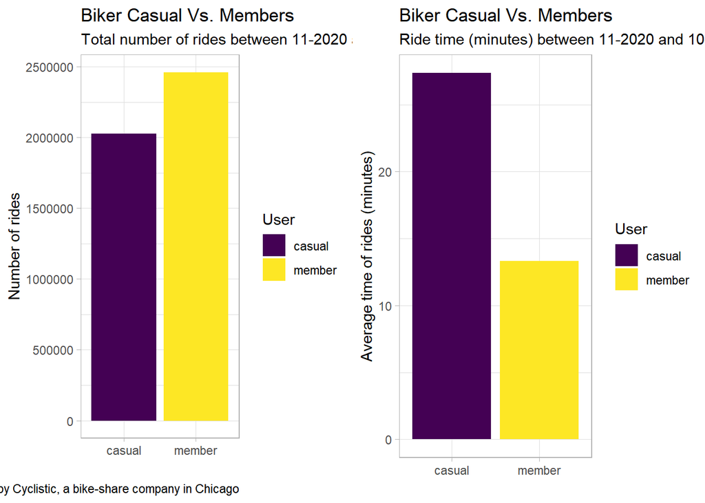

```r
# Are there differences in biking time and number of rides between members and casuals over the last year
grid.arrange(p1, p2, nrow = 1)
```

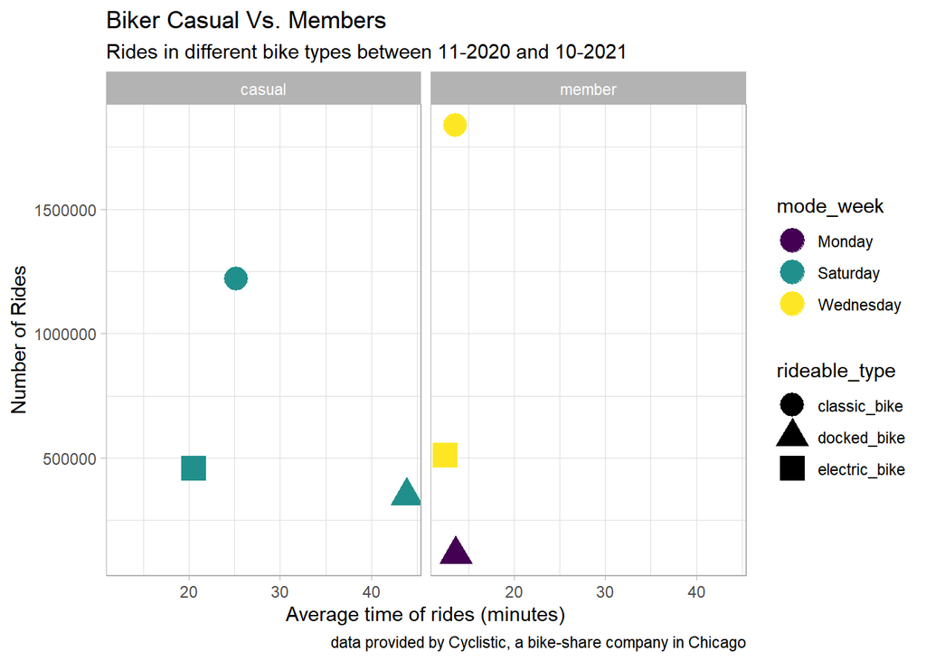

```r
# Does bike type influences the length or number of rides between members and casuals?
p3
```

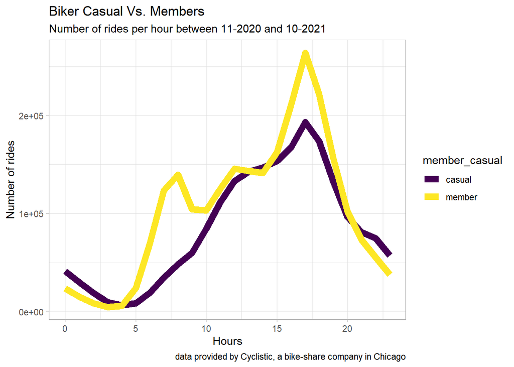

```r
# Are the differences during the day that we should account for?
p4
```

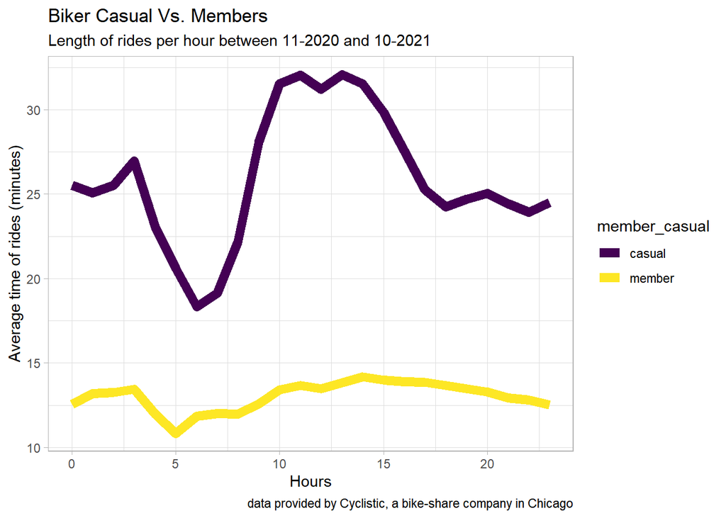

```r
p5
```

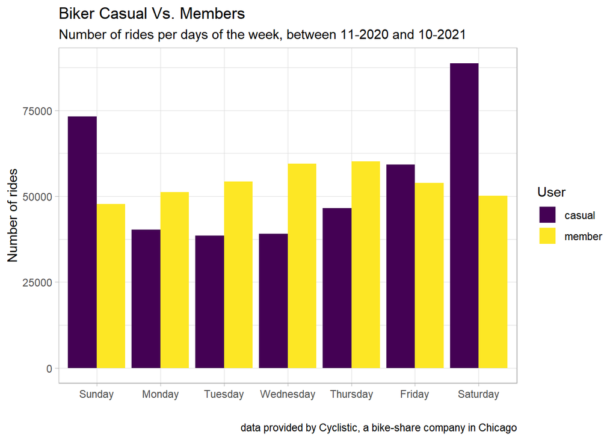

```r
# Are the differences during the week days that we should account for?
p6
```

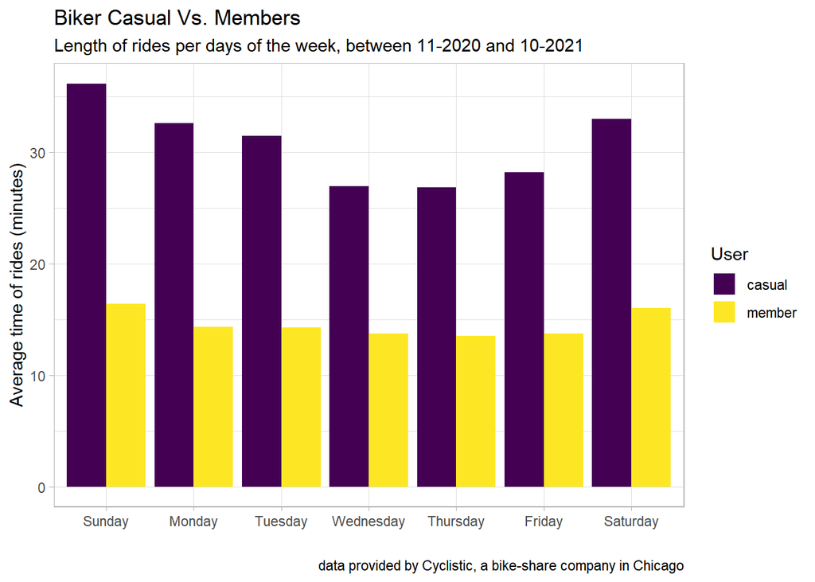

```r
p7
```

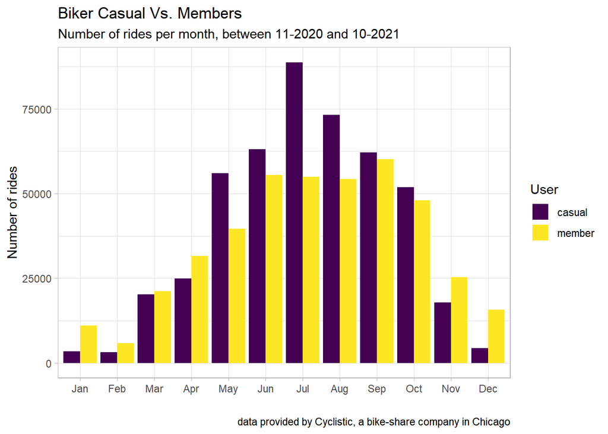

```r
# Are the differences during the months that we should account for?
p8
```

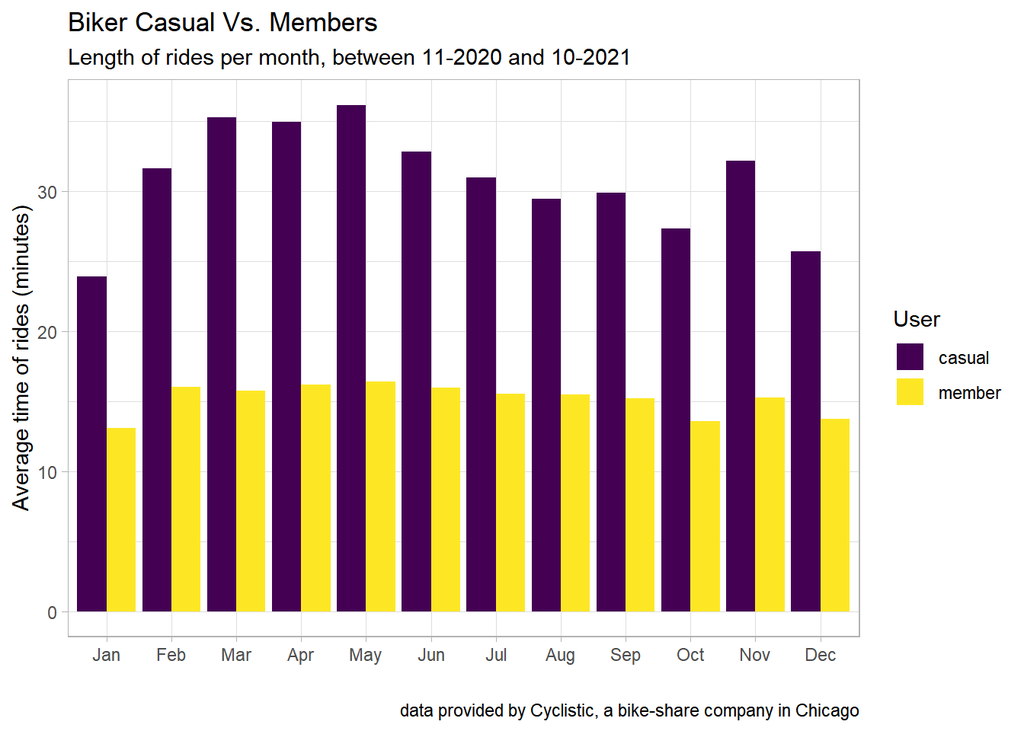

```r
p9
```

## 6. Act

### 6.3 Additional data for future studies

- The trajectory of each ride.
- The cost of each ride for casuals.
- The cost of an annual subscription.